# Supplementary Doc 4

Jelto de Jong

12/06/2021

## Fourth supplementary coding document used to build and tune the machine learning models for the business analytics and management master thesis of Jelto de Jong

First, the final dataset used for the machine learning part is loaded

```r
MlDataset <- read.csv("MlDataset.csv")
MlDataset$EPS_Movement <- as.factor(MlDataset$EPS_Movement)
```

A train test split is first created with an 80-20 distinction

```r
library(tidymodels)
library(dplyr)

set.seed(12)
model_split <- initial_split(MlDataset, prop = 0.8, strata = EPS_Movement)
```

The train and test set are then specified and immediately, a 10-fold cross-validation set is defined that will be used to tune the models

```r
data_train <- training(model_split)
data_test <- testing(model_split)

set.seed(12)
cv_folds <- vfold_cv(data_train, v = 10, strata = EPS_Movement)
```

## Lasso regression

The first machine learning model that is set up is the lasso linear regression. The first step is to create the model recipe by using all the data and removing the description variables.

```r
library(glmnet)
logreg_recipe <-  recipe(EPS_Movement ~ ., data = data_train)  %>%  step_rm(Year, endDate, Ticker, Publication, OneYearForwardEPS)
```

The model set up is then continued by making sure the shrinkage parameter will be tuned and a workflow is created with the specified recipe and model

```r
lasso_logreg <- logistic_reg(penalty = tune(), mixture = 1) %>% set_engine("glmnet")
lasso_wf <- workflow() %>%
  add_recipe(logreg_recipe) %>%
  add_model(lasso_logreg)
```

```r
grid_lasso <- tibble(penalty = 10^(seq(from = -5, to = -1, length.out = 100)))
```

The metrics used to test the performance are then specified, followed by tuning the model to obtain the optimal shrinkage parameter

```r
class_metrics <- metric_set(accuracy, kap, roc_auc)
lasso_tune <- lasso_wf %>%
  tune_grid(resamples = cv_folds,
            grid = grid_lasso,
            metrics = class_metrics)
```

The training metrics can then be obtained and the tuning grid can then be visualised

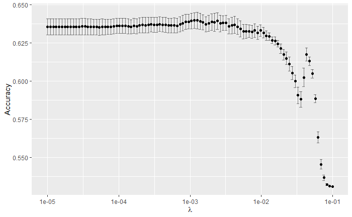

The best shrinkage parameter is then selected by looking at the parameter within one standard error of the best model to avoid shrinking the coefficients too much. As can be seen, the optimal parameter is 0.005

| penalty | .metric | .estimator | mean | n | std_err | .config | .best | .bound |
| --- | --- | --- | --- | --- | --- | --- | --- | --- |
| 0.004641589 | accuracy | binary | 0.6356572 | 10 | 0.005119007 | Preprocessor1_Model067 | 0.6396767 | 0.63448 |

The workflow is then finalised to be able to apply the model on the test set

```r
lasso_wf_tuned
```

```
== Workflow ====================================================================================================
Preprocessor: Recipe
Model: logistic_reg()

-- Preprocessor ------------------------------------------------------------------------------------------------
1 Recipe Step

* step_rm()

-- Model -------------------------------------------------------------------------------------------------------
Logistic Regression Model Specification (classification)

Main Arguments:
  penalty = 0.00464158883361278
  mixture = 1

Computational engine: glmnet
```

```r
lasso_last_fit <- lasso_wf_tuned %>%
  last_fit(model_split, metrics = class_metrics)
```

The variable importance can be shown as follows

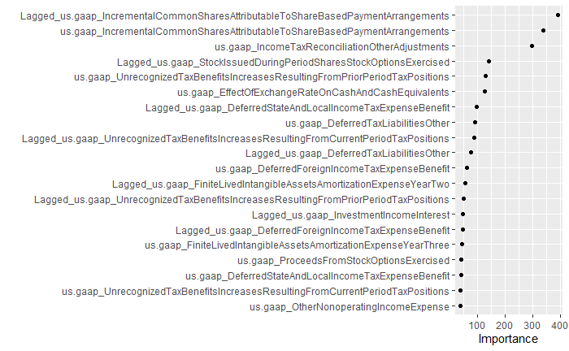

## Random Forests

The second model that will be applied is the Random Forests model. First of all, a recipe is created that show what dependent and independent variables have been used in the model

```r
library("ranger")
library("doParallel")

rf_recipe <- recipe(EPS_Movement ~ ., data = data_train) %>% step_rm(Year, endDate, Ticker, Publication, OneYearForwardEPS)
```

```r
rf_model_tune <- rand_forest(mtry = tune(), trees = 500) %>%
  set_mode("classification") %>%
  set_engine("ranger")
```

A workflow is then created that combines the recipe and the tuning specifications.

```r
rf_tune_wf
```

[output not shown]

After specifying the used metrics, the system is requested to run parallel models and the model is tuned

```r
class_metrics <- metric_set(accuracy, kap,  roc_auc)

registerDoParallel()
set.seed(12)
rf_tune_res <- tune_grid(
  rf_tune_wf,
  resamples = cv_folds,
  grid = tibble(mtry = c(63:65)),
  metrics = class_metrics
)
```

The tuning metrics are then obtained and it is shown that an mtry of 65 results in the best accuracy

```r
rf_tune_res %>%
  collect_metrics()

rf_tune_res %>%
  collect_metrics() %>%
  filter(.metric %in% c("roc_auc", "accuracy", "kap")) %>%
  ggplot(aes(x = mtry, y = mean, ymin = mean - std_err, ymax = mean + std_err,
             colour = .metric)) +
  geom_errorbar() +
  geom_line() +
  geom_point() +
  facet_grid(.metric ~ ., scales = "free_y")
```

[figure not shown]

This is then stored and the workflow is finalised and applied on the test set

```r
rf_final_wf
```

```
== Workflow ====================================================================================================
Preprocessor: Recipe
Model: rand_forest()

-- Preprocessor ------------------------------------------------------------------------------------------------
1 Recipe Step

* step_rm()

-- Model -------------------------------------------------------------------------------------------------------
Random Forest Model Specification (classification)

Main Arguments:
  mtry = 65
  trees = 500

Computational engine: ranger
```

The variable importance can be shown as follows

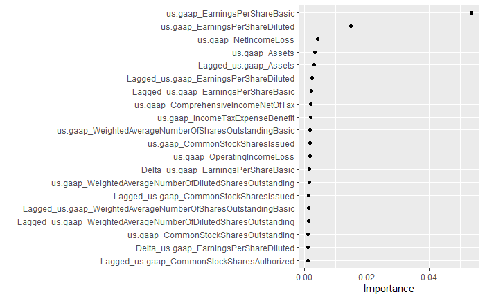

## Gradient Boosting Machines

The final machine learning model that is applied is the Gradient Boosting Machine algorithm.

```r
library("tidymodels")
library("doParallel")
library("themis")
library("xgboost")
```

First of all, the recipe is created where the variables in the model have been specified

```r
xgb_recipe <- recipe(EPS_Movement ~ ., data = data_train) %>% step_rm(Year, endDate, Ticker, Publication, OneYearForwardEPS)
```

The tuning model is then created where all parameters except for the stop parameter will be tuned

```r
xgb_model_tune <-
  boost_tree(trees = tune(), tree_depth = tune(),
             learn_rate = tune(), stop_iter = 1000) %>%
  set_mode("classification") %>%
  set_engine("xgboost")
```

The workflow can then be created where the recipe and the model specifications have been combined

```r
xgb_tune_wf <- workflow() %>%
  add_recipe(xgb_recipe) %>%
  add_model(xgb_model_tune)
xgb_tune_wf
```

```
== Workflow ====================================================================================================
Preprocessor: Recipe
Model: boost_tree()

-- Preprocessor ------------------------------------------------------------------------------------------------
1 Recipe Step

* step_rm()

-- Model -------------------------------------------------------------------------------------------------------
Boosted Tree Model Specification (classification)

Main Arguments:
  trees = tune()
  tree_depth = tune()
  learn_rate = tune()
  stop_iter = 1000

Computational engine: xgboost
```

```r
2:3
```

```
[1] 2 3
```

The model is then tuned after defining the class metrics

```r
class_metrics <- metric_set(accuracy, kap,  roc_auc)

registerDoParallel()
set.seed(12)

xgb_tune_res <- tune_grid(
  xgb_tune_wf,
  resamples = cv_folds,
  grid = xgb_grid,
  metrics = class_metrics
)
```

These metrics are then obtained and based on the best acurracy, the final parameter combination has been chosen

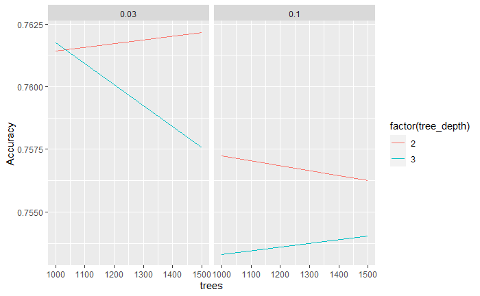

These parameters have then been specified in the final model

```r
xgb_final_wf
```

```
== Workflow ====================================================================================================
Preprocessor: Recipe
Model: boost_tree()

-- Preprocessor ------------------------------------------------------------------------------------------------
1 Recipe Step

* step_rm()

-- Model -------------------------------------------------------------------------------------------------------
Boosted Tree Model Specification (classification)

Main Arguments:
  trees = 1500
  tree_depth = 2
  learn_rate = 0.03
  stop_iter = 1000

Computational engine: xgboost
```

This model is then applied on the test set to obtain the final results

```r
xgb_final_fit <- xgb_final_wf %>%
  last_fit(model_split, metrics = class_metrics)
```

The variable importance can be shown as follows

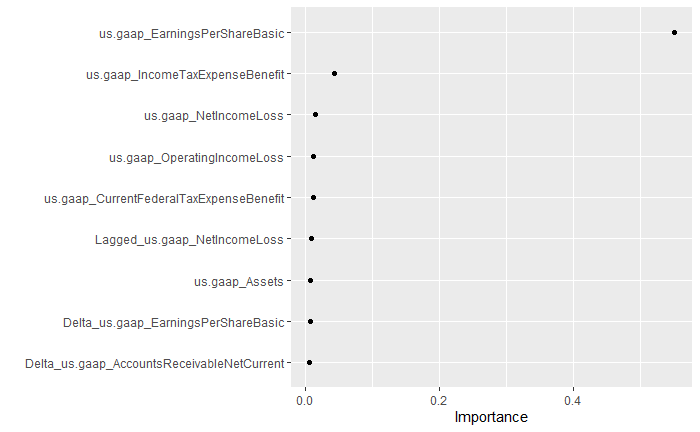

A final prediction model that will be used are the earnings movement predictions obtained from IBES, which has been cleaned and made comparable by using the following code

```r
IBES <- read.csv("IBES-Forecasts2.csv")

IBES$Fiscal_Year_End  <- as.character(as.Date(as.character(IBES$Fiscal_Year_End ),format="%Y%m%d"))
IBES$Prediction_Date  <- as.character(as.Date(as.character(IBES$Prediction_Date),format="%Y%m%d"))
IBES$Announcement_Date <- as.character(as.Date(as.character(IBES$Announcement_Date),format="%Y%m%d"))
IBES$Actual_Date <- as.character(as.Date(as.character(IBES$Actual_Date),format="%Y%m%d"))

## Only take predictions fewer than 1 day away from report filing
IBES$diff_in_days <- as.numeric(difftime(as.character(IBES$Prediction_Date), as.character(IBES$Announcement_Date), units = c("days")))

IBES <- IBES[IBES$diff_in_days <= 1,]
IBES_Match <- IBES %>% select(Ticker, Fiscal_Year_End, Predicted_EPS, Actual.EPS) %>% group_by(Ticker, Fiscal_Year_End) %>% summarise(mean_P_EPS = mean(Predicted_EPS, na.rm = T), mean_A_EPS = mean(Actual.EPS, na.rm = T))

data_test2 <- testing(model_split)
data_test2$endDate <- as.character(as.Date(as.character(data_test2$endDate),format="%d/%m/%Y"))
Combined <- left_join(data_test2, IBES_Match, by = c("Ticker" = "Ticker", "endDate" = "Fiscal_Year_End"))
Combined$MoveIBES <- ifelse(Combined$mean_P_EPS-Combined$mean_A_EPS>0,1,0)
Combined$MoveIBES <- ifelse(is.na(Combined$MoveIBES), as.numeric(Combined$EPS_Movement)-1, Combined$MoveIBES)
```

Now that all models have been acquired/tuned and applied on the test set, a final output file can be created where the predictions are stored and that can be used to compare these predictions. This is first of all done by adding the year, size and sector features to a summary file

```r
ID <- read.csv("Identifying.csv")

## Create summary table used in data chapter
colnames(ID) <- c("Ticker", "Sic", "Remove")
SUMMARY <- left_join(MlDataset, ID, by = ("Ticker" = "Ticker"))
SUMMARY <- SUMMARY %>% select(Ticker, Year, us.gaap_Assets, Sic, EPS_Movement)
```

Following this, the test set is stored and linked to the file with descriptive features

```r
SUMMARY <- SUMMARY %>% distinct(Ticker, Sic)
Combined <- left_join(Combined, SUMMARY, by = c("Ticker" = "Ticker"))

Combined$Size <- ifelse(Combined$us.gaap_Assets<10000000, "<10M",
ifelse(Combined$us.gaap_Assets>10000000 & Combined$us.gaap_Assets<50000000,"10M-50M",
ifelse(Combined$us.gaap_Assets>50000000 & Combined$us.gaap_Assets<200000000,"50M-200M",
ifelse(Combined$us.gaap_Assets>200000000 & Combined$us.gaap_Assets<500000000,"200M-500M",
ifelse(Combined$us.gaap_Assets>500000000 & Combined$us.gaap_Assets<1000000000,"500M-1B",
ifelse(Combined$us.gaap_Assets>1000000000 & Combined$us.gaap_Assets<2000000000,"1B-2B",
ifelse(Combined$us.gaap_Assets>2000000000 & Combined$us.gaap_Assets<5000000000,"2B-5B",
ifelse(Combined$us.gaap_Assets>5000000000 & Combined$us.gaap_Assets<10000000000,"5B-10B",
ifelse(Combined$us.gaap_Assets>10000000000,">10B","")))))))))


Combined$Industry <- ifelse(Combined$Sic <1000, "Agriculture, forestry and fishing",
ifelse(Combined$Sic>=1000 & Combined$Sic<1500,"Mining",
ifelse(Combined$Sic>=1500 & Combined$Sic<1800,"Construction",
ifelse(Combined$Sic>=2000 & Combined$Sic<4000,"Manufacturing",
ifelse(Combined$Sic>=4000 & Combined$Sic<5000,"Transportation, communication and utilities",
ifelse(Combined$Sic>=5000 & Combined$Sic<6000,"Wholesale and retail trade",
ifelse(Combined$Sic>=7000 & Combined$Sic<9000,"Services",
ifelse(Combined$Sic>=9000 & Combined$Sic<10000,"Public administration",""))))))))
```

The predictions from the models on the test set are then stored, and will be used to compare the results

```r
tmp <- lasso_last_fit %>% collect_predictions() %>% select(.pred_class)
tmp <- as.numeric(tmp$.pred_class) -1
Combined$LassoPredictions <- tmp

tmp <- rf_final_fit %>% collect_predictions() %>% select(.pred_class)
tmp <- as.numeric(tmp$.pred_class) -1
Combined$RFPredictions <- tmp

tmp <- xgb_final_fit %>% collect_predictions() %>% select(.pred_class)
tmp <- as.numeric(tmp$.pred_class) -1
Combined$GBMPredictions <- tmp

Combined <- Combined %>% select(endDate, Ticker, Year, EPS_Movement, MoveIBES, Sic, Size, Industry, LassoPredictions, RFPredictions, GBMPredictions)

#write.csv(Combined, "test_comparison.csv", row.names = FALSE)
```